# ps2.Rmd

Sijun Zhang UMid: 89934761

2019/10/10

# Problem Set 2

## Problem 1

```r
library(tidyverse)
# read in the  data: -----------------------------------------------------------
## This data will be used in the question.
url_base <- 'https://www.eia.gov/consumption/residential/data/2015/csv/'

recs_file <- './recs2015_public_v4.csv'
if ( !file.exists(recs_file) ) {
  recs_url <- sprintf('%s/recs2015_public_v4.csv', url_base)
  recs <- readr::read_delim(recs_url, delim = ',')
  readr::write_delim(recs, path = recs_file, delim = ',')
} else {
  recs <- readr::read_delim(recs_file, delim = ',')
}
```

First we read data from the csv document.

### National Average Home Temperature at Night in Winter

```r
# Input: recc2015_public_v4.csv
# Output: the national average home temperature at night in winter,
# among homes that use space heating
winter_tmp_heated <- recs %>%
  transmute(DOEID, winter_tmp = TEMPNITE, space_heated = HEATHOME, weight = NWEIGHT) %>%
  filter((space_heated == 1) ) %>%
  replace_na(list(weight=0))

# Convert weights to long: ----------------------------------------------------
weights_long <- recs %>%
  filter(HEATHOME == 1) %>%
  select(DOEID, BRRWT1:BRRWT96) %>%
  gather(key = 'repl', value = 'w', BRRWT1:BRRWT96)

# Join home type to weights: --------------------------------------------------
winter_tmp_heated_rep <- weights_long %>%
  left_join(winter_tmp_heated %>% mutate(DOEID = as.integer(DOEID)), by='DOEID')

# Check nothing is lost
if( nrow(weights_long) != nrow(winter_tmp_heated_rep) ) {
  stop("DOEID mismatch!")
}

winter_tmp_heated_avg_rep <- winter_tmp_heated_rep %>%
  group_by(repl) %>%
  summarize(winter_tmp_avg_r = sum(winter_tmp * w) / sum(w))

winter_tmp_heated_avg <- winter_tmp_heated %>%
  group_by(space_heated) %>%
  summarize(winter_tmp_avg = sum(winter_tmp * weight) / sum(weight))

# in this problem we all use \epsilon = 0.5
winter_tmp_heated_avg_num <- as.numeric(winter_tmp_heated_avg[,2])
winter_tmp_heated_stderr <- 2 * sqrt(mean( {sapply(winter_tmp_heated_avg_rep[,2], as.numeric) - winter_tmp_heated_avg_num}^2 ))
winter_tmp_heated_lwr <- winter_tmp_heated_avg_num - qnorm(0.975) * winter_tmp_heated_stderr
winter_tmp_heated_upr <- winter_tmp_heated_avg_num + qnorm(0.975) * winter_tmp_heated_stderr

sprintf(paste0('The national average home temperature at night in winter is %f,',
        ' among homes using space heating, ', 'and the upperbound is %f, and the ',
        'lower bound is %f'),
        winter_tmp_heated_avg_num, winter_tmp_heated_upr, winter_tmp_heated_lwr )
```

```
## [1] "The national average home temperature at night in winter is 68.105179, among homes using space heating, and the upperbound is 68.283863, and the lower bound is 67.926495"
```

### The Proportion of Homes using Each Level of “Main Space Heating Fuel”

#### Decoding the Census Division and Census (2010) Urban Type

```r
decode_fuel = function(x) {
  if(!is.numeric(x)) stop('decode_fuel expects numeric input indexed from 1!')

  re <- as.character( factor(x, levels = c(1, 2, 3, 5, 7, 21),
                             labels = c('Natural_gas',
                                        'Propane',
                                        'Fuel_oil_kerosene',
                                        'Electricity',
                                        'Wood',
                                        'Some_other_fuel')
                             ))

  return(re)
}

decode_all_fuel = function(x) {
  return(sapply(x,decode_fuel))
}

decode_division = function(x) {
  if(!is.numeric(x)) stop('decode_divsion expects numeric input indexed from 1!')
  y <- x
  re <- switch (y,
                'New England',
                'Middle Atlantic',
                'East North Central',
                'West North Central',
                'South Atlantic',
                'East South Central',
                'West South Central',
                'Mountain North',
                'Mountain South',
                'Pacific')
  return(re)
}

decode_all_division = function(x) {
  return(sapply(x,decode_division))
}

decode_urban = function(x) {
  re <- as.character( factor(x, levels = c('U', 'C', 'R'),
                            labels = c('Urban Area', 'Urban Cluster', 'Rural')
                            ))
  return(re)
}

decode_all_urban = function(x) {
  return(sapply(x,decode_urban))
}
```

The above code tranform the numeric value of urban type and division information to their exact meanings.

#### Proportion Table

```r
recs_fuel<- recs %>%
  transmute(DOEID, fuel_type = FUELHEAT, divis = DIVISION, urban_type = UATYP10,
            space_heated = HEATHOME, weight = NWEIGHT) %>%
  filter((fuel_type > 0) & (space_heated == 1) ) %>%
  mutate(fuel_type = decode_all_fuel(fuel_type),urban_type = decode_all_urban(urban_type),
         divis = decode_all_division(divis))

recs_fuel_rep <- weights_long %>%
  left_join(recs_fuel %>% mutate( DOEID=as.integer(DOEID) ) , by='DOEID' )

# Check nothing is lost
if( nrow(weights_long) != nrow(recs_fuel_rep) ) {
  stop("DOEID mismatch!")
}

recs_fuel_prop_rep <- recs_fuel_rep %>%
  group_by(divis,urban_type, fuel_type, repl) %>%
  summarize(sum_fuel = sum(w)) %>%
  tidyr::pivot_wider(names_from = fuel_type,
                     values_from = sum_fuel, values_fill = list(sum_fuel = 0)) %>%
  mutate(Total =Natural_gas + Propane + Fuel_oil_kerosene + Electricity + Wood + Some_other_fuel,
         Natural_gas_r = 100 * Natural_gas / Total,
         Propane_r = 100 * Propane / Total,
         Fuel_oil_kerosene_r = 100 * Fuel_oil_kerosene / Total,
         Electricity_r = 100 * Electricity / Total,
         Wood_r = 100 * Wood / Total,
         Some_other_fuel_r = 100 * Some_other_fuel / Total) %>%
  select(divis, urban_type, repl, Natural_gas_r, Propane_r, Fuel_oil_kerosene_r,
         Electricity_r, Wood_r,Some_other_fuel_r)

recs_fuel_prop <- recs_fuel %>%
  group_by(divis,urban_type, fuel_type) %>%
  summarize(sum_fuel = sum(weight)) %>%
  tidyr::pivot_wider(names_from = fuel_type,
                     values_from = sum_fuel, values_fill = list(sum_fuel = 0)) %>%
  mutate(Total =Natural_gas + Propane + Fuel_oil_kerosene + Electricity + Wood + Some_other_fuel,
         Natural_gas = 100 * Natural_gas / Total,
         Propane = 100 * Propane / Total,
         Fuel_oil_kerosene = 100 * Fuel_oil_kerosene / Total,
         Electricity = 100 * Electricity / Total,
         Wood = 100 * Wood / Total,
         Some_other_fuel = 100 * Some_other_fuel / Total) %>%
  select(-Total)

recs_fuel_prop_rep <- recs_fuel_prop_rep %>%
  left_join(recs_fuel_prop, by = c ('divis','urban_type'))

# Comptue standard errors: ----------------------------------------------------
recs_fuel_prop <- recs_fuel_prop_rep %>%
  group_by(divis, urban_type) %>%
  summarize(Natural_gas = mean(Natural_gas), Propane = mean(Propane), Fuel_oil_kerosene =
            mean(Fuel_oil_kerosene), Electricity = mean(Electricity), Wood = mean(Wood),
            Some_other_fuel = mean(Some_other_fuel),
            stderr_ng = 2*sqrt(mean({Natural_gas_r - Natural_gas}^2)),
            stderr_p = 2*sqrt(mean({Propane_r - Propane}^2)),
            stderr_k = 2*sqrt(mean({Fuel_oil_kerosene_r - Fuel_oil_kerosene}^2)),
            stderr_e = 2*sqrt(mean({Electricity_r - Electricity}^2)),
            stderr_w = 2*sqrt(mean({Wood_r - Wood}^2)),
            stderr_o = 2*sqrt(mean({Some_other_fuel_r - Some_other_fuel}^2))
            ) %>%
  group_by(divis, urban_type) %>%
  transmute(Natural_gas = paste0(as.character(round(Natural_gas,2)),' +- ' ,
                                 as.character(round(qnorm(0.975)*stderr_ng,2)), '%' ),
            Propane = paste0(as.character(round(Propane,2)),' +- ' ,
                             as.character(round(qnorm(0.975)*stderr_p,2)), '%' ),
            Fuel_oil_kerosene = paste0(as.character(round(Fuel_oil_kerosene,2)),' +- ' ,
                                       as.character(round(qnorm(0.975)*stderr_k,2)), '%' ),
            Electricity = paste0(as.character(round(Electricity,2) ),' +- ' ,
                                 as.character(round(qnorm(0.975)*stderr_e,2) ), '%' ),
            Wood = paste0(as.character(round(Wood,2) ),' +- ' ,
                          as.character(round(qnorm(0.975)*stderr_w) ), '%' ),
            Some_other_fuel = paste0(as.character(round(Some_other_fuel,2) ),' +- ' ,
                                     as.character(round(qnorm(0.975)*stderr_o,2) ), '%' )
            )


# Output a markdown table: -----------------------------------------------------
cap_title <- '**Table 1.** *Proprtion of homes using each level of “main space heating fuel”.*'
cap_text0 <- 'Each row shows unique combination of census division and census (2010) urban type.'
cap <- paste(cap_title, cap_text0)

cols <- c('division', 'urban type', 'Natural_gas',
         'Propane', 'Fuel_oil_kerosene', 'Electricity', 'Wood', 'Some_other_fuel')

knitr::kable(recs_fuel_prop, digits=1, caption=cap, col.names = cols)
```

**Table 1.** *Proprtion of homes using each level of “main space heating fuel”.* Each row shows unique combination of census division and census (2010) urban type.

| division | urban type | Natural_gas | Propane | Fuel_oil_kerosene | Electricity | Wood | Some_other_fuel |
| --- | --- | --- | --- | --- | --- | --- | --- |
| East North Central | Rural | 44.51 +- 13.03% | 20.58 +- 13.81% | 0 +- 0% | 30.84 +- 11.2% | 4.07 +- 2% | 0 +- 0% |
| East North Central | Urban Area | 80.56 +- 4.59% | 0.48 +- 0.71% | 0.43 +- 0.85% | 17.79 +- 4.2% | 0.73 +- 1% | 0 +- 0% |
| East North Central | Urban Cluster | 81.85 +- 9.27% | 1.42 +- 2.61% | 0 +- 0% | 14.78 +- 7.46% | 1.95 +- 2% | 0 +- 0% |
| East South Central | Rural | 16.58 +- 12.84% | 19.24 +- 4.87% | 1.12 +- 2.43% | 56.1 +- 12.19% | 6.95 +- 4% | 0 +- 0% |
| East South Central | Urban Area | 35.86 +- 14.14% | 0 +- 0% | 0 +- 0% | 64.14 +- 14.14% | 0 +- 0% | 0 +- 0% |
| East South Central | Urban Cluster | 24.72 +- 18.91% | 6.31 +- 5.01% | 0.7 +- 2.21% | 68.26 +- 15.61% | 0 +- 0% | 0 +- 0% |
| Middle Atlantic | Rural | 17.37 +- 15.41% | 12.69 +- 7.89% | 27.16 +- 9.2% | 13.1 +- 11.17% | 24.33 +- 6% | 5.36 +- 3.78% |
| Middle Atlantic | Urban Area | 65.76 +- 7.94% | 1.2 +- 1.32% | 15.93 +- 5.17% | 16.02 +- 4.22% | 0.55 +- 1% | 0.54 +- 0.68% |
| Middle Atlantic | Urban Cluster | 68.21 +- 23.58% | 5.54 +- 6.19% | 10.25 +- 9.22% | 7.47 +- 9.26% | 8.52 +- 14% | 0 +- 0% |
| Mountain North | Rural | 61.07 +- 13.29% | 13.43 +- 7.72% | 0 +- 0% | 14.34 +- 15.08% | 10.46 +- 5% | 0.7 +- 1.71% |
| Mountain North | Urban Area | 83.38 +- 9.89% | 0.67 +- 1.19% | 0 +- 0% | 15.31 +- 9.23% | 0.64 +- 1% | 0 +- 0% |
| Mountain North | Urban Cluster | 83.92 +- 13.57% | 0 +- 0% | 0 +- 0% | 16.08 +- 13.57% | 0 +- 0% | 0 +- 0% |
| Mountain South | Rural | 16.16 +- 29.07% | 33.96 +- 4.14% | 0 +- 0% | 12.18 +- 13.03% | 37.7 +- 24% | 0 +- 0% |
| Mountain South | Urban Area | 53.8 +- 19.21% | 0.85 +- 2.53% | 0 +- 0% | 45.35 +- 19.3% | 0 +- 0% | 0 +- 0% |
| Mountain South | Urban Cluster | 100 +- 0% | 0 +- 0% | 0 +- 0% | 0 +- 0% | 0 +- 0% | 0 +- 0% |
| New England | Rural | 0.43 +- 0.82% | 20.77 +- 5.46% | 57.21 +- 7.77% | 0.93 +- 1.06% | 20.67 +- 11% | 0 +- 0% |
| New England | Urban Area | 56.45 +- 14.73% | 3.01 +- 3.72% | 26.32 +- 10.64% | 11.91 +- 5.85% | 2.31 +- 3% | 0 +- 0% |
| New England | Urban Cluster | 36.99 +- 24.59% | 3.08 +- 2.6% | 46.66 +- 22.58% | 8.95 +- 4.96% | 4.32 +- 6% | 0 +- 0% |
| Pacific | Rural | 4.85 +- 3.21% | 18.44 +- 15.6% | 5.1 +- 3.45% | 49.54 +- 12.52% | 22.07 +- 12% | 0 +- 0% |
| Pacific | Urban Area | 65.85 +- 7.07% | 0.11 +- 0.22% | 0.24 +- 0.51% | 32.33 +- 6.79% | 1.48 +- 1% | 0 +- 0% |
| Pacific | Urban Cluster | 32.31 +- 14.49% | 0 +- 0% | 0 +- 0% | 63.05 +- 18.95% | 4.65 +- 6% | 0 +- 0% |
| South Atlantic | Rural | 8.7 +- 6.11% | 8.93 +- 4.46% | 5.01 +- 4% | 70.99 +- 8.14% | 6.36 +- 5% | 0 +- 0% |
| South Atlantic | Urban Area | 36.65 +- 7.65% | 2.1 +- 1.77% | 3.55 +- 1.94% | 56.74 +- 6.75% | 0.96 +- 1% | 0 +- 0% |
| South Atlantic | Urban Cluster | 34.95 +- 27.38% | 3.02 +- 3.27% | 0.91 +- 2.41% | 61.12 +- 25% | 0 +- 0% | 0 +- 0% |
| West North Central | Rural | 24.2 +- 12.44% | 29.8 +- 10.25% | 1.61 +- 1.72% | 27.88 +- 9.4% | 16.52 +- 5% | 0 +- 0% |
| West North Central | Urban Area | 77.29 +- 8.21% | 1.51 +- 1.35% | 0 +- 0% | 21.2 +- 8.25% | 0 +- 0% | 0 +- 0% |
| West North Central | Urban Cluster | 80.01 +- 12.95% | 2.7 +- 3.11% | 0.76 +- 2.18% | 14.9 +- 10.07% | 0 +- 0% | 1.63 +- 3.24% |
| West South Central | Rural | 26.72 +- 9.59% | 15.1 +- 7.06% | 0 +- 0% | 51.72 +- 11.2% | 6.46 +- 4% | 0 +- 0% |
| West South Central | Urban Area | 43.88 +- 7.75% | 0 +- 0% | 0 +- 0% | 55.9 +- 7.87% | 0.22 +- 0% | 0 +- 0% |
| West South Central | Urban Cluster | 43.76 +- 12.62% | 0 +- 0% | 0 +- 0% | 56.24 +- 12.62% | 0 +- 0% | 0 +- 0% |

The 95% confidence intervals of each proportion of the fuel used in space heating are shown in the above table, the first value for each proportion represent the estimation of proportion using final weights as full sample.

### Plot Comparing Home Temperature

```r
# Transforming the inappliable temperature data from label -2 to NA.
fill_tmp_NA = function(x) {
  if (x == -2) {re <- NA}
  else {re <- x}
  return(re)
}

fill_all_tmp_NA = function(x) {
  sapply(x, fill_tmp_NA)
}


# in the Fay’s balanced repeated replication (BRR) method of estimating standard error
# we set \epsilon = 0.5 and R = the number of replicate subsamples then the estimated
# standard error could be reduced to var(samples) /

recs_tmp <- recs %>%
  transmute(DOEID, divis = DIVISION, urban_type = UATYP10, d = TEMPHOME,
            dn = TEMPGONE, n = TEMPNITE, weight = NWEIGHT) %>%
  mutate(divis = decode_all_division(divis), urban_type = decode_all_urban(urban_type),
         d = fill_all_tmp_NA(d), dn = fill_all_tmp_NA(dn),
         n = fill_all_tmp_NA(n), weight = weight)


recs_tmp_avg <- recs_tmp %>%
  gather(key = 'tmp_type', value = 'tmp', d, dn, n) %>%
  group_by(divis, urban_type, tmp_type) %>%
  summarize(tmp_avg = sum(sapply(tmp, as.numeric) * weight, na.rm = T) / sum(weight))

weights_long_all <- recs %>%
  select(DOEID, BRRWT1:BRRWT96) %>%
  gather(key = 'repl', value = 'w', BRRWT1:BRRWT96)

recs_tmp_rep <- weights_long_all %>%
  left_join(recs_tmp %>% mutate( DOEID=as.integer(DOEID) ) , by='DOEID' )

# Check nothing is lost
if( nrow(recs_tmp_rep) != nrow(weights_long_all) ) {
    stop("DOEID mismatch!")
  }

recs_tmp_avg_rep <- recs_tmp_rep %>%
  gather(key = 'tmp_type', value = 'tmp', d, dn, n) %>%
  group_by(divis, urban_type, repl, tmp_type) %>%
  summarize(tmp_avg_r = sum(sapply(tmp, as.numeric) * w, na.rm = T) / sum(w) )

recs_tmp_avg_rep <- recs_tmp_avg_rep %>%
  left_join(recs_tmp_avg, by = c ('divis','urban_type', 'tmp_type'))

recs_tmp_avg <- recs_tmp_avg_rep %>%
  group_by(divis, urban_type, tmp_type) %>%
  summarize(tmp_avg = mean(tmp_avg),
            stderr = 2*sqrt(mean({tmp_avg_r - tmp_avg}^2))) %>%
  group_by(divis, urban_type, tmp_type) %>%
  mutate(lwr = tmp_avg - qnorm(.975)*stderr,
         upr = tmp_avg + qnorm(.975)*stderr
         )
```

Firstly, I prepare the average temperature for each case and pre-calculated the upper and lower bound of the average temperature.

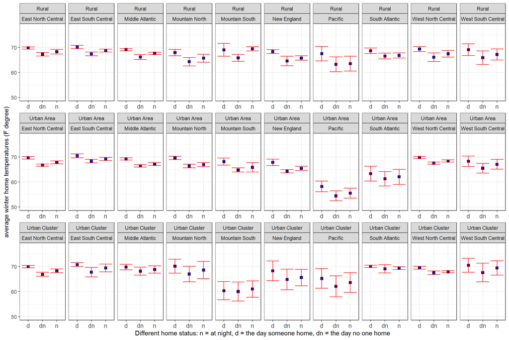

```r
p_sfd <- recs_tmp_avg %>%
  ungroup() %>%
  ggplot( aes( x = tmp_type, y = tmp_avg) ) +
  geom_point( col='navy', pch = 15, cex=2) +
  geom_errorbar( aes(ymin=lwr, ymax=upr), col='red' ) +
  facet_wrap(~urban_type+divis, scales='free_x', nrow=3, ncol=10) +
  theme_bw() +
  theme( axis.text.x =
           element_text(
             angle = 0,
             size = 10
           ), plot.margin = margin(0.2,0.2,0.2,0.2,"cm") ) +
  ylim( c(50, 78) ) +
  xlab('Different home status: n = at night, d = the day someone home, dn = the day no one home') +
  ylab('average winter home temperatures (F degree)')
p_sfd
```

### The Median difference between the daytime (with someone home) and nighttime temperatures

```r
decode_behavior = function(x) {
  if(!is.numeric(x)) stop('decode_behavior expects numeric input indexed from 1!')

  re <- as.character( factor(x, levels = c(1, 2, 3, 4, 5, 9),
                             labels = c('Set one temperature and leave it there most of the time',
                                        'Manually adjust the temperature at night or when no one is at home',
                                        paste0('Program the thermostat to automatically adjust the',
                                        ' temperature during the day and night at certain times'),
                                        'Turn equipment on or off as needed',
                                        'Our household does not have control over the equipment',
                                        'Other')
  ))
  return(re)
}

decode_behavior_all = function(x) {
  return(sapply(x, decode_behavior))
}

# Key values for each observation: --------------------------------------------
recs_mtmp <- recs %>%
  filter(HEATHOME == 1) %>%
  transmute(DOEID, bhvr = decode_behavior_all(EQUIPMUSE), weight = NWEIGHT, day = TEMPHOME, night = TEMPNITE) %>%
  replace_na(list(weight=0))  %>%
  filter( (bhvr > 0) & (day > 0) & (night >0))

# Convert weights to long: ----------------------------------------------------
weights_long <- recs %>%
  filter(HEATHOME == 1) %>%
  select(DOEID, BRRWT1:BRRWT96) %>%
  gather(key = 'repl', value = 'w', BRRWT1:BRRWT96)

recs_mtmp_rep <- weights_long %>%
  left_join(recs_mtmp %>% mutate( DOEID=as.integer(DOEID) ) , by='DOEID' )

# Check nothing is lost
if( nrow(recs_mtmp_rep) != nrow(weights_long) ) {
  stop("DOEID mismatch!")
}

recs_mtmp_med <- recs_mtmp %>%
  gather(key = 'tmp_type', value = 'tmp', day, night)  %>%
  arrange(tmp) %>%
  group_by(bhvr, tmp_type) %>%
  summarize(tmp_med = tmp[min(which(cumsum(weight) > 0.5*sum(weight)))] )


recs_mtmp_med_rep <- recs_mtmp_rep %>%
  gather(key = 'tmp_type', value = 'tmp', day, night) %>%
  group_by(bhvr, tmp_type, repl) %>%
  summarize(tmp_med_r = tmp[min(which(cumsum(w) > 0.5*sum(w)))] )

recs_mtmp_med_rep <- recs_mtmp_med_rep %>%
  left_join(recs_mtmp_med, by = c ('bhvr', 'tmp_type'))


recs_mtmp_med <- recs_mtmp_med_rep %>%
  group_by(bhvr, tmp_type) %>%
  summarize(tmp_med = mean(tmp_med),
            stderr = 2*sqrt(mean({tmp_med_r - tmp_med}^2))) %>%
  group_by(bhvr, tmp_type) %>%
  mutate(lwr = tmp_med - qnorm(.975)*stderr,
         upr = tmp_med + qnorm(.975)*stderr
  )



recs_mtmp_med_tib <- recs_mtmp_med %>%
  tidyr::pivot_wider(names_from = tmp_type, values_from = c(tmp_med, stderr,
                                                            lwr, upr))
```

```r
# Output a markdown table: -----------------------------------------------------
cap_title <- '**Table 2.** *The (national) median difference between the daytime (with someone home) and nighttime temperatures”.*'
cap_text0 <- 'Each row shows each level of “main heating equipment household behavior”.'
cap <- paste(cap_title, cap_text0)

cols <- c('equipment behavior', 'tmp_med_day', 'tmp_med_night',
         'stderr_day', 'stderr_night', 'lwr_day', 'lwr_night', 'upr_day', 'upr_night')

knitr::kable(recs_mtmp_med_tib, digits=4, caption=cap, col.names = cols)
```

**Table 2.** *The (national) median difference between the daytime (with someone home) and nighttime temperatures”.* Each row shows each level of “main heating equipment household behavior”.

| equipment behavior | tmp_med_day | tmp_med_night | stderr_day | stderr_night | lwr_day | lwr_night | upr_day | upr_night |
| --- | --- | --- | --- | --- | --- | --- | --- | --- |
| Manually adjust the temperature at night or when no one is at home | 70 | 68 | 10.9221 | 12.0899 | 48.5931 | 44.3042 | 91.4069 | 91.6958 |
| Other | 69 | 65 | 15.6418 | 19.9875 | 38.3426 | 25.8252 | 99.6574 | 104.1748 |
| Our household does not have control over the equipment | 70 | 70 | 8.4508 | 6.7915 | 53.4367 | 56.6888 | 86.5633 | 83.3112 |
| Program the thermostat to automatically adjust the temperature during the day and night at certain times | 69 | 67 | 5.6384 | 8.5147 | 57.9489 | 50.3115 | 80.0511 | 83.6885 |
| Set one temperature and leave it there most of the time | 70 | 70 | 6.1981 | 6.4872 | 57.8519 | 57.2854 | 82.1481 | 82.7146 |
| Turn equipment on or off as needed | 70 | 68 | 11.0491 | 11.1878 | 48.3441 | 46.0723 | 91.6559 | 89.9277 |

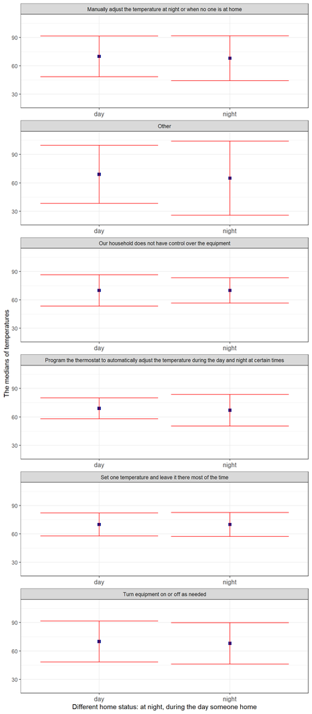

```r
p_med <- recs_mtmp_med %>%
  ungroup() %>%
  ggplot( aes( x = tmp_type, y = tmp_med) ) +
  geom_point( col='navy', pch = 15, cex=2) +
  geom_errorbar( aes(ymin=lwr, ymax=upr), col='red' ) +
  facet_wrap(~bhvr, scales='free_x', nrow=6) +
  theme_bw() +
  theme( axis.text.x =
           element_text(
             angle = 0,
             size = 10
           ), plot.margin = margin(0.2,0.2,0.2,0.2,"cm") ) +
  ylim( c(20, 110) ) +
  xlab('Different home status: at night, during the day someone home') +
  ylab('The medians of temperatures')
p_med
```

## Problem Set 2

### Source the codes used in PS 1 Question 3

```r
# libraries including ----------------------------------------------------------
source('./ps2_q2_funcs.R', encoding = 'UTF-8')
library(tidyverse)
library(mousetrap)
library(lme4)
```

### Load the data and examine the columns

```r
# read in the  data: -----------------------------------------------------------

factor_to_numeric_list = function(x) {
  tmp = str_replace(x, '(\\[)', '') %>%
    str_replace('(\\])', '') %>%
    str_split(', ')
  return(sapply(tmp, as.numeric))
}

data_prep = function(x) {
  return(
    x %>%
    transmute(subject = subject_nr, trial = count_trial,
            x = factor_to_numeric_list(xpos_get_response),
            y = factor_to_numeric_list(ypos_get_response),
            tm = factor_to_numeric_list(timestamps_get_response),
            correct)
  )
}

sakh <- data_prep(mousetrap::KH2017_raw)
lapply(sakh, class)
```

```
## $subject
## [1] "integer"
##
## $trial
## [1] "integer"
##
## $x
## [1] "list"
##
## $y
## [1] "list"
##
## $tm
## [1] "list"
##
## $correct
## [1] "integer"
```

In this part we use “list” columns for each component.

### Apply to measure curvature

```r
normalize_dim3 = function(x,y,t) {
  a = unname(unlist(x))
  b = unname(unlist(y))
  c = unname(unlist(t))
  tmp = unname(cbind(a,b,c))
  return(list(normalize(tmp)) )
}

measure_curv_list = function(x) {
  tmp = (matrix(unlist(x), ncol = 3))
  return(list(measure_curvature(tmp)) )
}

unlist_curv = function(x,f) {
  tmp = unname(unlist(x))
  if(f == 'tot_dist') return(tmp[1])
  if(f == 'max_abs_dev') return(tmp[2])
  if(f == 'avg_abs_dev') return(tmp[3])
  if(f == 'AUC') return(tmp[4])
}

norm_sakh <- sakh %>%
  filter(correct == 1) %>%
  group_by(subject, trial) %>%
  summarize(norm_xyt = normalize_dim3(x,y,tm))

meas <- norm_sakh %>%
  group_by(subject,trial) %>%
  summarize(curv = measure_curv_list(norm_xyt) ) %>%
  group_by(subject,trial) %>%
  summarize( tot_dist = unlist_curv(curv, 'tot_dist'),
         max_abs_dev = unlist_curv(curv, 'max_abs_dev'),
         avg_abs_dev = unlist_curv(curv, 'avg_abs_dev'),
         AUC = unlist_curv(curv, 'AUC')
         )

con_expl <- mousetrap::KH2017_raw %>%
  transmute(subject = subject_nr, trial = count_trial,
            Condition = Condition, Exemplar = Exemplar,correct) %>%
  filter(correct == 1) %>%
  select(-correct)
options(digits = 7)
meas <- meas %>%
  left_join(con_expl, by=c('subject', 'trial'))
head(meas)
```

```
## # A tibble: 6 x 8
## # Groups:   subject [1]
##   subject trial tot_dist max_abs_dev avg_abs_dev     AUC Condition Exemplar
##     <int> <int>    <dbl>       <dbl>       <dbl>   <dbl> <fct>     <fct>
## 1       1     2    1063.        85.1        6.03  46527. Typical   Loewe
## 2       1     3    1033.        65.4       14.6   16242. Typical   Kaninch~
## 3       1     4    1153.        99.2       18.2   54516. Atypical  Seeloewe
## 4       1     5    1050.        64.3       20.7   32054. Typical   Alligat~
## 5       1     6    1962.       624.        92.5  228193. Atypical  Pinguin
## 6       1     7    1587.       598.        90.9  315864. Typical   Katze
```

The meas data frame contains the curvature measurements for all correct responses and the head of it is shown in the above table.

### Fit linear mixed models exploring how each curvature

```r
# fit linear mixed model ----------------------------------------------------

meas_fitting <- meas %>%
  filter(AUC > 0) %>%
  group_by(subject,trial) %>%
  summarize(tot_dist_log = log(tot_dist),
            max_abs_dev_log = log(max_abs_dev),
            avg_abs_dev_log = log(avg_abs_dev),
            AUC_log = log(AUC),
            Condition = factor(Condition, levels = c('Typical','Atypical'),
                               labels = c(0,1) ),
            Exemplar = factor(Exemplar, levels = c('Aal','Alligator', 'Chamaeleon',
                                                   'Falke', 'Fledermaus',
                                                   'Goldfisch','Hai','Hund',
                                                   'Kaninchen','Katze',
                                                   'Klapperschlange','Lachs',
                                                   'Loewe','Pferd','Pinguin',
                                                   'Schmetterling','Seeloewe',
                                                   'Spatz','Wal'),
                              labels = c(1:19)))

m1 <- lmer(tot_dist_log~Condition+(1|Exemplar)+(1|subject), data = meas_fitting )
m2 <- lmer(max_abs_dev_log~Condition+(1|Exemplar)+(1|subject), data = meas_fitting )
m3 <- lmer(avg_abs_dev_log~Condition+(1|Exemplar)+(1|subject), data = meas_fitting )
m4 <- lmer(AUC_log~Condition+(1|Exemplar)+(1|subject), data = meas_fitting )

re1 <- cbind( matrix(lme4::fixef(m1)[2]), matrix(confint(m1)['Condition1',],nrow=1), mean(fitted.values(m1)) )
```

```
## Computing profile confidence intervals ...
```

```r
re2 <- cbind( matrix(lme4::fixef(m2)[2]), matrix(confint(m2)['Condition1',],nrow=1), mean(fitted.values(m2)) )
```

```
## Computing profile confidence intervals ...
```

```r
re3 <- cbind( matrix(lme4::fixef(m3)[2]), matrix(confint(m3)['Condition1',],nrow=1), mean(fitted.values(m3)) )
```

```
## Computing profile confidence intervals ...
```

```r
re4 <- cbind( matrix(lme4::fixef(m4)[2]), matrix(confint(m4)['Condition1',],nrow=1), mean(fitted.values(m4)) )
```

```
## Computing profile confidence intervals ...
```

```r
re <- data.frame(rbind(re1,re2,re3,re4), row.names = c('tot_dist_log', 'max_abs_dev_log',
                                                       'avg_abs_dev_log','AUC_log'))
re <- cbind(re, exp(re[,1:4]) )
re <- cbind(re, re[5] / re[8])
names(re) <- c('Coef of Condition log', '2.5% lwr log', '97.5% upr log', 'mean log',
               'Coef of Condition', '2.5% lwr', '97.5% upr', 'mean', 'Coef / mean')
```

```r
# Output a markdown table: -----------------------------------------------------
cap_title <- '**Table 3.** *The effect Condition have on the curvature measurements.*'
cap <- paste(cap_title, cap_text0)

cols <- c('Coef of Condition log', '2.5% lwr log', '97.5% upr log', 'mean log',
               'Coef of Condition', '2.5% lwr', '97.5% upr', 'mean', 'Coef / mean')

knitr::kable(re, digits=4, caption=cap, col.names = cols)
```

|  | Coef of Condition log | 2.5% lwr log | 97.5% upr log | mean log | Coef of Condition | 2.5% lwr | 97.5% upr | mean | Coef / mean |
| --- | --- | --- | --- | --- | --- | --- | --- | --- | --- |
| tot_dist_log | 0.1579 | 0.0838 | 0.2320 | 7.1935 | 1.1710 | 1.0874 | 1.2611 | 1330.7576 | 0.0009 |
| max_abs_dev_log | 0.5048 | 0.2736 | 0.7362 | 4.9026 | 1.6567 | 1.3147 | 2.0880 | 134.6441 | 0.0123 |
| avg_abs_dev_log | 0.6460 | 0.3815 | 0.9109 | 3.2563 | 1.9080 | 1.4645 | 2.4865 | 25.9540 | 0.0735 |
| AUC_log | 0.4058 | 0.2057 | 0.6063 | 11.1280 | 1.5005 | 1.2284 | 1.8337 | 68049.3931 | 0.0000 |

From the above table, we find the coefficient of Condition on “the average absolute deviation of the observed trajectory from the direct path” is the maximum. Moreover, the expectation of average absolute deviation is also the smallest, which means the unit change in Condition variable is more influential in changing the distribution of average absolute deviation. Considering the two facts in average absolute deviation, we can conclude that the Condition has largest effect on the average absolute deviation.